# Home Work Assignment - 01

Critical Thinking Group 5

# Overview

The data set contains approximately 2200 records. Each record represents a professional baseball team from the years 1871 to 2006 inclusive. Each record has the performance of the team for the given year, with all of the statistics adjusted to match the performance of a 162 game season. We will be exploring, analyzing, and modeling the data set to predict a number of wins for a team using Ordinary Least Square (OLS).  
To attain our objective, we will be following the below best practice steps and guidelines:  
1 -Data Exploration  
2 -Data Preparation  
3 -Build Models  
4 -Select Models

# 1 Data Exploration Analysis

In section we will explore and gain some insights into the dataset by pursuing the below high level steps and inquiries:  
-Variable identification  
-Variable Relationships  
-Data summary analysis  
-Outliers and Missing Values Identification

## 1.1 Variable identification

First let’s display and examine the data dictionary or the data columns as shown in table 1.

Variable Definition

| VARIABLE_NAME | DEFINITION | THEORETICAL_EFFECT |
| --- | --- | --- |
| INDEX | Identification Variable (do not use) | None |
| TARGET_WINS | Number of wins | Target |
| TEAM_BATTING_H | Base Hits by batters (1B,2B,3B,HR) | Positive Impact on Wins |
| TEAM_BATTING_2B | Doubles by batters (2B) | Positive Impact on Wins |
| TEAM_BATTING_3B | Triples by batters (3B) | Positive Impact on Wins |
| TEAM_BATTING_HR | Homeruns by batters (4B) | Positive Impact on Wins |
| TEAM_BATTING_BB | Walks by batters | Positive Impact on Wins |
| TEAM_BATTING_HBP | Batters hit by pitch (get a free base) | Positive Impact on Wins |
| TEAM_BATTING_SO | Strikeouts by batters | Negative Impact on Wins |
| TEAM_BASERUN_SB | Stolen bases | Positive Impact on Wins |
| TEAM_BASERUN_CS | Caught stealing | Negative Impact on Wins |
| TEAM_FIELDING_E | Errors | Negative Impact on Wins |
| TEAM_FIELDING_DP | Double Plays | Positive Impact on Wins |
| TEAM_PITCHING_BB | Walks allowed | Negative Impact on Wins |
| TEAM_PITCHING_H | Hits allowed | Negative Impact on Wins |
| TEAM_PITCHING_HR | Homeruns allowed | Negative Impact on Wins |
| TEAM_PITCHING_SO | Strikeouts by pitchers | Positive Impact on Wins |

We notice that all variables are numeric. The variable names seem to follow certain naming pattern to highlight certain arithmetic relationships. In other words, we can compute the number of ‘1B’ hits by taking the difference between overall hits and ‘2B’, ‘3B’, ‘HR’. Although such naming and construct is not recommended in normalized database design ( as it violates third normal form), it is very frequent practice in the data analytics.

Our predictor input is made of 15 variables. And our dependent variable is one variable called TARGET_WINS.

Please note that we will not be using INDEX variable as it serves as just an identifier for each row. And has no relationships to other variables.

## 1.2 Data Summary Analysis

In this section, we will create summary data to better understand the initial relationship variables have with our dependent variable using correlation, central tendency, and dispersion As shown in table 2.

Data Summary

|  | mean | sd | median | trimmed |
| --- | --- | --- | --- | --- |
| TARGET_WINS | 80.79086 | 15.75215 | 82.0 | 81.31229 |
| TEAM_BATTING_H | 1469.26977 | 144.59120 | 1454.0 | 1459.04116 |
| TEAM_BATTING_2B | 241.24692 | 46.80141 | 238.0 | 240.39627 |
| TEAM_BATTING_3B | 55.25000 | 27.93856 | 47.0 | 52.17563 |
| TEAM_BATTING_HR | 99.61204 | 60.54687 | 102.0 | 97.38529 |
| TEAM_BATTING_BB | 501.55888 | 122.67086 | 512.0 | 512.18331 |
| TEAM_BATTING_SO | 735.60534 | 248.52642 | 750.0 | 742.31322 |
| TEAM_BASERUN_SB | 124.76177 | 87.79117 | 101.0 | 110.81188 |
| TEAM_BASERUN_CS | 52.80386 | 22.95634 | 49.0 | 50.35963 |
| TEAM_BATTING_HBP | 59.35602 | 12.96712 | 58.0 | 58.86275 |
| TEAM_PITCHING_H | 1779.21046 | 1406.84293 | 1518.0 | 1555.89517 |
| TEAM_PITCHING_HR | 105.69859 | 61.29875 | 107.0 | 103.15697 |
| TEAM_PITCHING_BB | 553.00791 | 166.35736 | 536.5 | 542.62459 |
| TEAM_PITCHING_SO | 817.73045 | 553.08503 | 813.5 | 796.93391 |
| TEAM_FIELDING_E | 246.48067 | 227.77097 | 159.0 | 193.43798 |
| TEAM_FIELDING_DP | 146.38794 | 26.22639 | 149.0 | 147.57789 |

Missing Data and Data Correlation

|  | Missing | Correlation |
| --- | --- | --- |
| TARGET_WINS | 0 | 1.0000000 |
| TEAM_BATTING_H | 0 | 0.3887675 |
| TEAM_BATTING_2B | 0 | 0.2891036 |
| TEAM_BATTING_3B | 0 | 0.1426084 |
| TEAM_BATTING_HR | 0 | 0.1761532 |
| TEAM_BATTING_BB | 0 | 0.2325599 |
| TEAM_BATTING_SO | 102 | -0.0317507 |
| TEAM_BASERUN_SB | 131 | 0.1351389 |
| TEAM_BASERUN_CS | 772 | 0.0224041 |
| TEAM_BATTING_HBP | 2085 | 0.0735042 |
| TEAM_PITCHING_H | 0 | -0.1099371 |
| TEAM_PITCHING_HR | 0 | 0.1890137 |
| TEAM_PITCHING_BB | 0 | 0.1241745 |
| TEAM_PITCHING_SO | 102 | -0.0784361 |
| TEAM_FIELDING_E | 0 | -0.1764848 |
| TEAM_FIELDING_DP | 286 | -0.0348506 |

Based on table 2 and Table 3, we can make the below observations:

1.Some of the variables like TEAM_PITCHING_H, TEAM_PITCHING_SO and TEAM_FIELDING_E seem to have outliers which is evident from the mean, median and trimmed mean values.

2.TEAM_BATTING_HBP and TEAM_BASERUN_CS seems to be missing a lot of values which casts doubt on its usefulness as a predictor. Maybe a flag for presense or absense of TEAM_BATTING_HBP and TEAM_BASERUN_CS might be a better predictor. Also given the fact that there is low correlation, we decided to exclude these 2 variables from any missing value or outlier treatment.

3.Most of the variables seem to indicate a positive / negative correlation in line with the theoretical effect. However, the following stand out as they show a correlation opposite to the theoretical impact: TEAM_BASERUN_CS, TEAM_PITCHING_HR, TEAM_PITCHING_BB, TEAM_PITCHING_SO and TEAM_FIELDING_DP. Lets evaluate these variables further once we fix any missing values or outliers.

4. We will impute the missing values in TEAM_BATTING_SO, FIELDING_DP, BASERUN_SB and TEAM_PITCHING_SO since it has lesser missing values even though there is low correlation. So we will create new variables that will have the respective missing values handled.

## 1.3 Outliers and Missing Values Identification

In this section we look at boxplots to determine the outliers in variables and decide on whether to act on the outliers.

Lets do some univariate analysis. We will look at the Histogram and Boxplot for each variable to detect outliers if any and treat it accordingly.

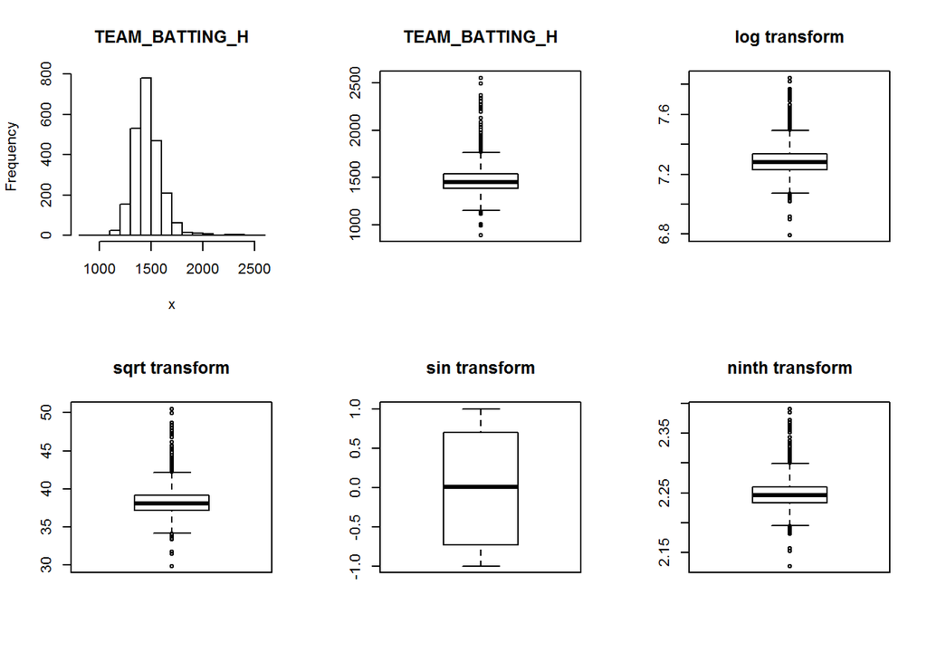

TEAM_BATTING_H Transformation

***Please note that we have created similar figures to figure 1 above for each remaining variable. However, we hid the remaining figures for ease of streamlining the report as they have similar shapes. However, we have drawn the below observations from each remaining figure.

- For TEAM_BATTING_H, we can see that there are quite a few outliers, both at the upper and lower end. Accordingly, we decide to create a new variable that will have the outlier fixed.
- For TEAM_BATTING_2B, we can see that there are quite a few outliers, both at the upper and a single outlier at the lower end. For this variable we decide to create a new variable that will have the outliers fixed.
- For TEAM_BATTING_3B, we can see that there are quite a few outliers at the upper end. For this variable we decide to create a new variable that will have the outliers fixed.
- For TEAM_BATTING_HR, we can see that there are no outliers.
- For TEAM_BATTING_BB, we can see that there are quite a few outliers, both at the upper and lower end. For this variable we decide to create a new variable that will have the outlier fixed.
- For TEAM_BATTING_SO, we can see that there are no outliers. No further action needed for this variable.
- For TEAM_BASERUN_SB, we can see that there are quite a few outliers at the upper end. For this variable we decide to create a new variable that will have the outlier fixed.
- For TEAM_FIELDING_E, we can see that there are quite a few outliers at the upper end. For this variable we decide to create a new variable that will have the outlier fixed.
- For TEAM_FIELDING_DP, we can see that there are quite a few outliers, both at the upper and lower end. For this variable we decide to create a new variable that will have the outlier fixed.
- For TEAM_PITCHING_BB, we can see that there are quite a few outliers, both at the upper and lower end. For this variable we decide to create a new variable that will have the outlier fixed.
- For TEAM_PITCHING_H, we can see that there are quite a few outliers at the upper end. For this variable we decide to create a new variable that will have the outlier fixed.
- For TEAM_PITCHING_HR, we can see that there only 3 outliers at the upper end. For this variable we decide to create a new variable that will have the outlier fixed.
- For TEAM_PITCHING_SO, we can see that there are quite a few outliers at the upper and a single outlier on the lower end. For this variable we decide to create a new variable that will have the outlier fixed.

##### Please note that, in most of the cases above, we see that a SIN transformation seems to work well to take care of the outliers. We will go ahead and create these new variables respectively.

# 2. Data Preparation

Now that we have completed the preliminary analysis, we will be cleaning and consolidating data into one dataset for use in analysis and modeling. We will be puring the belwo steps as guidlines:  
- Outliers treatment  
- Missing values treatment  
- Data transformation

## 2.1 Outliers treatment

For outliers, we will create 2 sets of variables.

The first set uses the capping method. In this method, we will replace all outliers that lie outside the 1.5 times of IQR limits. We will cap it by replacing those observations less than the lower limit with the value of 5th %ile and those that lie above the upper limit with the value of 95th %ile.

Accordingly we create the following new variables while retaining the original variables.

TEAM_BATTING_H_NEW  
TEAM_BATTING_2B_NEW  
TEAM_BATTING_3B_NEW  
TEAM_BATTING_BB_NEW  
TEAM_BASERUN_SB_NEW  
TEAM_FIELDING_E_NEW  
TEAM_FIELDING_DP_NEW  
TEAM_PITCHING_BB_NEW  
TEAM_PITCHING_H_NEW  
TEAM_PITCHING_HR_NEW  
TEAM_PITCHING_SO_NEW

Lets see how the new variables look in boxplots.

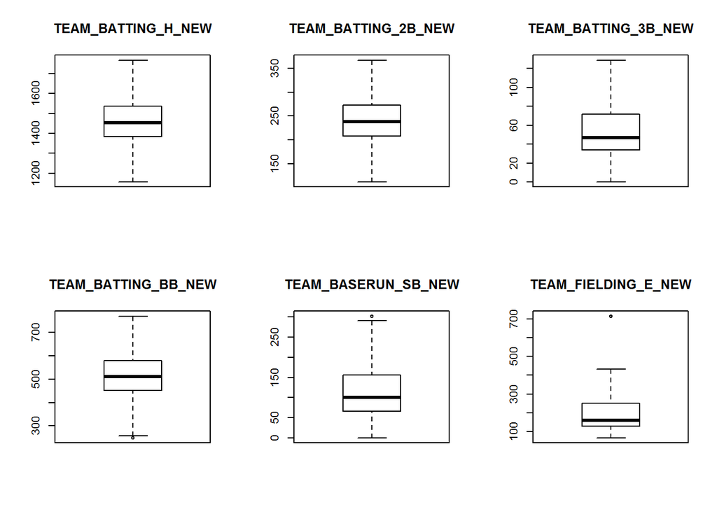

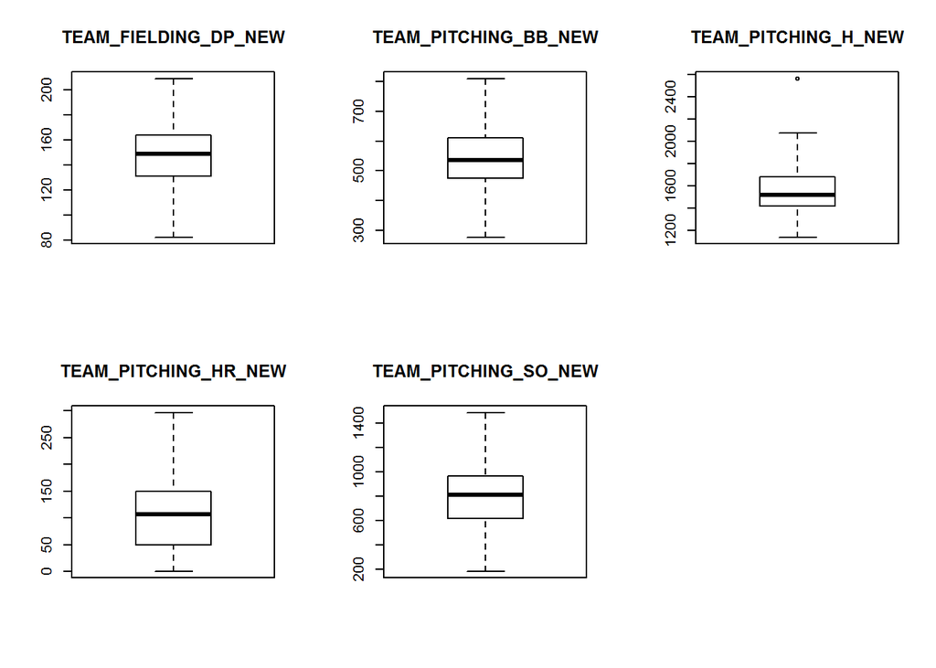

In the second set, we will use the sin transformation and create the following variables:

TEAM_BATTING_H_SIN  
TEAM_BATTING_2B_SIN  
TEAM_BATTING_3B_SIN  
TEAM_BATTING_BB_SIN  
TEAM_BASERUN_SB_SIN  
TEAM_FIELDING_E_SIN  
TEAM_FIELDING_DP_SIN  
TEAM_PITCHING_BB_SIN  
TEAM_PITCHING_H_SIN  
TEAM_PITCHING_HR_SIN  
TEAM_PITCHING_SO_SIN

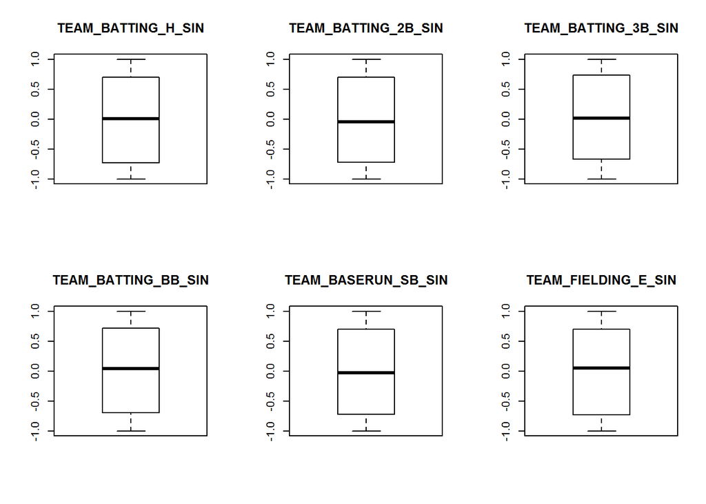

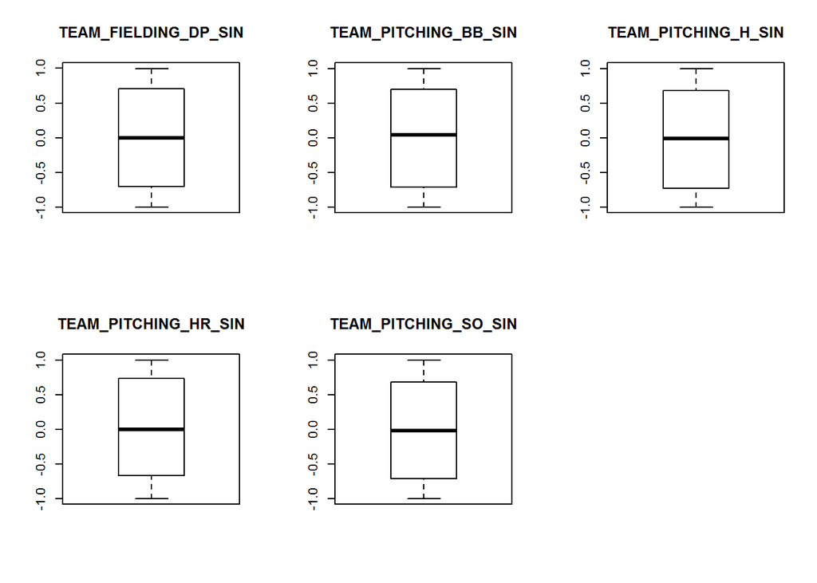

## 2.2 Missing values treatment

Next we impute missing values. Since we have handled outliers, we can go ahead and use the mean as impute values. As with outliers, we will go ahead and create new variables for the following:

TEAM_BATTING_SO_NEW

We will re-use the already created new variables for fixing the missing values for the below:

TEAM_PITCHING_SO_NEW  
TEAM_BASERUN_SB_NEW  
TEAM_FIELDING_DP_NEW

Lets now create some additional variables that might help us in out analysis.

## 2.3 Missing Flags

First we create flag variables to indicate whether TEAM_BATTING_HBP and TEAM_BASERUN_CS and missing. If the value is missing, we code it with 0 and if the value is present we code it with 1.  
We will name our missing flag variables as follow:  
TEAM_BATTING_HBP_Missing  
TEAM_BASERUN_CS_Missing

## 2.4 Ratios

Next we create some additional variables, that we think may be useful with the prediction. Here we create the following ratios:  
Hits_R = TEAM_BATTING_H/TEAM_PITCHING_H  
Walks_R = TEAM_BATTING_BB/TEAM_PITCHING_BB  
HomeRuns_R = TEAM_BATTING_HR/TEAM_PITCHING_HR  
Strikeout_R = TEAM_BATTING_SO/TEAM_PITCHING_SO

## 2.5 Calculated Variables

Finally, we will also create calculated variables as below:

1. TEAM_BATTING_EB (Extra Base Hits) = 2B + 3B + HR
2. TEAM_BATTING_1B (Singles by batters) = TEAM_BATTING_H - TEAM_BATTING_EB

## 2.6 Correlation for new variables

Lets see how the new variables stack up against wins.

```
## TEAM_BATTING_HBP_Missing  TEAM_BASERUN_CS_Missing                   Hits_R
##              0.002610647              0.004864215              0.095800033
##                  Walks_R               HomeRuns_R              Strikeout_R
##              0.083660245              0.013440964              0.063193881
##          TEAM_BATTING_EB          TEAM_BATTING_1B
##              0.344958150              0.217430135
```

All new variables seem to have a positive correlation with wins. However, some of them do not seem to have a strong correlation. Lets see how they perform while modeling.

# 3 Build Models

In this phase, we will build four models. The models independent variables will be based initially on the original data set variables, derived dataset variables, transformed dataset variables, and all variables in the dataset. In addition, for each model, we will perform a stepwise selection and stop at a point where we retain only those variables that have lower AIC (Akaike An Information Criterion). Recall (AIC) is a measure of the relative quality of statistical models for a given set of data. Given a collection of models for the data, AIC estimates the quality of each model, relative to each of the other models. Lower AIC leads to better quality model.

Below is a summary table showing models and their respective variables.

| VARIABLE_NAME | Comments | Theoretical.Effect | Model1 | Model2 | Model3 | Model4 |
| --- | --- | --- | --- | --- | --- | --- |
| TEAM_BATTING_H | Given | Positive | Y |  |  | Y |
| TEAM_BATTING_2B | Given | Positive | Y |  |  | Y |
| TEAM_BATTING_3B | Given | Positive | Y |  |  | Y |
| TEAM_BATTING_HR | Given | Positive | Y |  |  | Y |
| TEAM_BATTING_BB | Given | Positive | Y |  |  | Y |
| TEAM_BATTING_HBP | Given | Positive |  |  |  |  |
| TEAM_BATTING_SO | Given | Negative | Y |  |  | Y |
| TEAM_BASERUN_SB | Given | Positive | Y |  |  | Y |
| TEAM_BASERUN_CS | Given | Negative |  |  |  |  |
| TEAM_FIELDING_E | Given | Negative | Y |  |  | Y |
| TEAM_FIELDING_DP | Given | Positive | Y |  |  | Y |
| TEAM_PITCHING_BB | Given | Negative | Y |  |  | Y |
| TEAM_PITCHING_H | Given | Negative | Y |  |  | Y |
| TEAM_PITCHING_HR | Given | Negative | Y |  |  | Y |
| TEAM_PITCHING_SO | Given | Positive | Y |  |  | Y |
| TEAM_BATTING_H_NEW | Derived | Positive |  | Y |  | Y |
| TEAM_BATTING_2B_NEW | Derived | Positive |  | Y |  | Y |
| TEAM_BATTING_3B_NEW | Derived | Positive |  | Y |  | Y |
| TEAM_BATTING_BB_NEW | Derived | Positive |  | Y |  | Y |
| TEAM_BASERUN_SB_NEW | Derived | Positive |  | Y |  | Y |
| TEAM_FIELDING_E_NEW | Derived | Negative |  | Y |  | Y |
| TEAM_FIELDING_DP_NEW | Derived | Positive |  | Y |  | Y |
| TEAM_PITCHING_BB_NEW | Derived | Negative |  | Y |  | Y |
| TEAM_PITCHING_H_NEW | Derived | Negative |  | Y |  | Y |
| TEAM_PITCHING_HR_NEW | Derived | Negative |  | Y |  | Y |
| TEAM_PITCHING_SO_NEW | Derived | Positive |  | Y |  | Y |
| TEAM_BATTING_H_SIN | Derived | Positive |  |  | Y | Y |
| TEAM_BATTING_2B_SIN | Derived | Positive |  |  | Y | Y |
| TEAM_BATTING_3B_SIN | Derived | Positive |  |  | Y | Y |
| TEAM_BATTING_BB_SIN | Derived | Positive |  |  | Y | Y |
| TEAM_BASERUN_SB_SIN | Derived | Positive |  |  | Y | Y |
| TEAM_FIELDING_E_SIN | Derived | Negative |  |  | Y | Y |
| TEAM_FIELDING_DP_SIN | Derived | Positive |  |  | Y | Y |
| TEAM_PITCHING_BB_SIN | Derived | Negative |  |  | Y | Y |
| TEAM_PITCHING_H_SIN | Derived | Negative |  |  | Y | Y |
| TEAM_PITCHING_HR_SIN | Derived | Negative |  |  | Y | Y |
| TEAM_PITCHING_SO_SIN | Derived | Positive |  |  | Y | Y |
| TEAM_BATTING_HBP_Missing | Derived |  |  |  | Y | Y |
| TEAM_BASERUN_CS_Missing | Derived |  |  |  | Y | Y |
| Hits_R | Derived |  |  |  | Y | Y |
| Walks_R | Derived |  |  |  | Y | Y |
| HomeRuns_R | Derived |  |  |  | Y | Y |
| Strikeout_R | Derived |  |  |  | Y | Y |
| TEAM_BATTING_EB | Derived |  |  |  | Y | Y |
| TEAM_BATTING_1B | Derived |  |  |  | Y | Y |

## 3.1 Model One

In this model, we will be using the original variables. We will create model and we will highlight the variables that being recommended using the AIC value.  
First we will produce the summary model as per below:

```
##
## Call:
## lm(formula = TARGET_WINS ~ TEAM_BATTING_H + TEAM_BATTING_2B +
##     TEAM_BATTING_3B + TEAM_BATTING_HR + TEAM_BATTING_BB + TEAM_BATTING_SO +
##     TEAM_BASERUN_SB + TEAM_FIELDING_E + TEAM_FIELDING_DP + TEAM_PITCHING_BB +
##     TEAM_PITCHING_H + TEAM_PITCHING_HR + TEAM_PITCHING_SO, data = na.omit(data))
##
## Residuals:
##     Min      1Q  Median      3Q     Max
## -32.158  -7.254   0.135   6.945  29.884
##
## Coefficients:
##                   Estimate Std. Error t value Pr(>|t|)
## (Intercept)      58.941092   6.030409   9.774  < 2e-16 ***
## TEAM_BATTING_H   -0.031483   0.016426  -1.917  0.05543 .
## TEAM_BATTING_2B  -0.049301   0.008876  -5.554 3.19e-08 ***
## TEAM_BATTING_3B   0.183608   0.018989   9.669  < 2e-16 ***
## TEAM_BATTING_HR   0.141783   0.081347   1.743  0.08151 .
## TEAM_BATTING_BB   0.113365   0.042521   2.666  0.00774 **
## TEAM_BATTING_SO   0.026511   0.021975   1.206  0.22781
## TEAM_BASERUN_SB   0.069369   0.005539  12.525  < 2e-16 ***
## TEAM_FIELDING_E  -0.119149   0.007145 -16.676  < 2e-16 ***
## TEAM_FIELDING_DP -0.112120   0.012280  -9.131  < 2e-16 ***
## TEAM_PITCHING_BB -0.075474   0.040427  -1.867  0.06207 .
## TEAM_PITCHING_H   0.057619   0.014949   3.854  0.00012 ***
## TEAM_PITCHING_HR -0.040017   0.077904  -0.514  0.60754
## TEAM_PITCHING_SO -0.046960   0.020918  -2.245  0.02489 *
## ---
## Signif. codes:  0 '***' 0.001 '**' 0.01 '*' 0.05 '.' 0.1 ' ' 1
##
## Residual standard error: 10.18 on 1821 degrees of freedom
## Multiple R-squared:  0.4059, Adjusted R-squared:  0.4017
## F-statistic: 95.71 on 13 and 1821 DF,  p-value: < 2.2e-16
```

Next, we will step thru this model (model 1) and retain only those variables that have the most impact.

Based on the backward stepwise selection, below are the characteristics of the refined model :

- The Residual standard error is 10.18
- Multiple R-squared: 0.4058
- Adjusted R-squared: 0.4019
- F-statistic: 103.7 on 12 and 1822 DF
- p-value: < 2.2e-16

Coefficients for the refined model 1

|  | Coefficients |
| --- | --- |
| (Intercept) | 59.0548324 |
| TEAM_BATTING_H | -0.0338435 |
| TEAM_BATTING_2B | -0.0492679 |
| TEAM_BATTING_3B | 0.1834965 |
| TEAM_BATTING_HR | 0.1002629 |
| TEAM_BATTING_BB | 0.1183635 |
| TEAM_BATTING_SO | 0.0333161 |
| TEAM_BASERUN_SB | 0.0694647 |
| TEAM_FIELDING_E | -0.1188641 |
| TEAM_FIELDING_DP | -0.1123169 |
| TEAM_PITCHING_BB | -0.0803085 |
| TEAM_PITCHING_H | 0.0598130 |
| TEAM_PITCHING_SO | -0.0535232 |

Based on the above coefficients, we can see that some of the coefficients are counter-intutive to the Theoretical impact.

- TEAM_BATTING_H (-0.034), TEAM_BATTING_2B (-0.049), TEAM_FIELDING_DP (-0.112), TEAM_PITCHING_SO (-0.054) have a negative coefficient even though they are theoretically supposed to have a positive impact on wins. This means that a unit change in each of these variables will decrease the number of a wins.
- Similarly, TEAM_BATTING_SO (0.033), TEAM_PITCHING_H (0.06) have a positive coefficient even though they are theoretically supposed to have a negative impact on wins. This means that a unit change in each of these variables will increase the number of a wins.
- TEAM_BATTING_3B (0.183), TEAM_BATTING_HR (0.1), TEAM_BATTING_BB (0.118), TEAM_BASERUN_SB (0.069), TEAM_FIELDING_E (-0.119), TEAM_PITCHING_BB (-0.08) have the intended theoretical impact on wins. This means that a unit change in each of these variables will either decrease or increase the number of a wins as intended by the theoretical impact.

Since we have already seen this result in our data exploration phase, we will retain this model as is for comparision with other models.

## 3.2 Model Two

In this model (model2), we will be using the adjusted values based on our outlier treatment process. We will create model and we will highlight the variables that being recommended using the AIC value. First we will produce the summary model as per below:

```
##
## Call:
## lm(formula = TARGET_WINS ~ TEAM_BATTING_H_NEW + TEAM_BATTING_2B_NEW +
##     TEAM_BATTING_3B_NEW + TEAM_BATTING_BB_NEW + TEAM_BASERUN_SB_NEW +
##     TEAM_FIELDING_E_NEW + TEAM_FIELDING_DP_NEW + TEAM_PITCHING_BB_NEW +
##     TEAM_PITCHING_H_NEW + TEAM_PITCHING_HR_NEW + TEAM_PITCHING_SO_NEW,
##     data = na.omit(data))
##
## Residuals:
##     Min      1Q  Median      3Q     Max
## -54.032  -8.396   0.269   8.411  70.493
##
## Coefficients:
##                        Estimate Std. Error t value Pr(>|t|)
## (Intercept)          21.9620608  6.0558154   3.627 0.000294 ***
## TEAM_BATTING_H_NEW    0.0260878  0.0051203   5.095 3.78e-07 ***
## TEAM_BATTING_2B_NEW  -0.0003544  0.0096157  -0.037 0.970603
## TEAM_BATTING_3B_NEW   0.1257703  0.0182053   6.908 6.35e-12 ***
## TEAM_BATTING_BB_NEW   0.0511574  0.0083740   6.109 1.18e-09 ***
## TEAM_BASERUN_SB_NEW   0.0442051  0.0055102   8.022 1.65e-15 ***
## TEAM_FIELDING_E_NEW  -0.0216626  0.0029143  -7.433 1.49e-13 ***
## TEAM_FIELDING_DP_NEW -0.1041769  0.0140840  -7.397 1.95e-13 ***
## TEAM_PITCHING_BB_NEW -0.0314461  0.0074625  -4.214 2.61e-05 ***
## TEAM_PITCHING_H_NEW   0.0103825  0.0020683   5.020 5.58e-07 ***
## TEAM_PITCHING_HR_NEW  0.0751211  0.0089378   8.405  < 2e-16 ***
## TEAM_PITCHING_SO_NEW -0.0055230  0.0020750  -2.662 0.007830 **
## ---
## Signif. codes:  0 '***' 0.001 '**' 0.01 '*' 0.05 '.' 0.1 ' ' 1
##
## Residual standard error: 13.42 on 2264 degrees of freedom
## Multiple R-squared:  0.2779, Adjusted R-squared:  0.2744
## F-statistic: 79.21 on 11 and 2264 DF,  p-value: < 2.2e-16
```

Lets now step thru this model and retain only those variables that have the most impact.

Based on the backward stepwise selection, below are the characteristics of the refined model :

- The Residual standard error is 13.42
- Multiple R-squared: 0.2779
- Adjusted R-squared: 0.2747
- F-statistic: 87.16 on 10 and 2265 DF
- p-value: < 2.2e-16

Coefficients for the refined model 2

|  | Coefficients |
| --- | --- |
| (Intercept) | 22.0443242 |
| TEAM_BATTING_H_NEW | 0.0259818 |
| TEAM_BATTING_3B_NEW | 0.1258334 |
| TEAM_BATTING_BB_NEW | 0.0511472 |
| TEAM_BASERUN_SB_NEW | 0.0442132 |
| TEAM_FIELDING_E_NEW | -0.0216441 |
| TEAM_FIELDING_DP_NEW | -0.1041916 |
| TEAM_PITCHING_BB_NEW | -0.0314459 |
| TEAM_PITCHING_H_NEW | 0.0103832 |
| TEAM_PITCHING_HR_NEW | 0.0751231 |
| TEAM_PITCHING_SO_NEW | -0.0055425 |

Based on the above coefficients, we can see that some of the coefficients are counter-intutive to the Theoretical impact.

- TEAM_FIELDING_DP_NEW (-0.104), TEAM_PITCHING_SO_NEW (-0.006) have a negative coefficient even though they are theoretically supposed to have a positive impact on wins. This means that a unit change in each of these variables will decrease the number of a wins.
- Similarly, TEAM_PITCHING_H_NEW (0.01), TEAM_PITCHING_HR_NEW (0.075) have a positive coefficient even though they are theoretically supposed to have a negative impact on wins. This means that a unit change in each of these variables will increase the number of a wins.
- TEAM_BATTING_H_NEW (0.026), TEAM_BATTING_3B_NEW (0.126), TEAM_BATTING_BB_NEW (0.051), TEAM_BASERUN_SB_NEW (0.044), TEAM_FIELDING_E_NEW (-0.022), TEAM_PITCHING_BB_NEW (-0.031) have the intended theoretical impact on wins. This means that a unit change in each of these variables will either decrease or increase the number of a wins as intended by the theoretical impact.

However, since the correlation seems to have a minor impact, we will go ahead and retain this model for further comparision.

## 3.3 Model Three

In this model (model3), we will be using the derived values based on our variable transformation process. We will create model and we will highlight the variables that being recommended using the AIC value. First we will produce the summary model as per below:

```
##
## Call:
## lm(formula = TARGET_WINS ~ TEAM_BATTING_H_SIN + TEAM_BATTING_2B_SIN +
##     TEAM_BATTING_3B_SIN + TEAM_BATTING_BB_SIN + TEAM_BASERUN_SB_SIN +
##     TEAM_FIELDING_E_SIN + TEAM_FIELDING_DP_SIN + TEAM_PITCHING_BB_SIN +
##     TEAM_PITCHING_H_SIN + TEAM_PITCHING_HR_SIN + TEAM_PITCHING_SO_SIN +
##     TEAM_BATTING_HBP_Missing + TEAM_BASERUN_CS_Missing + Hits_R +
##     Walks_R + HomeRuns_R + Strikeout_R + TEAM_BATTING_EB + TEAM_BATTING_1B,
##     data = na.omit(data))
##
## Residuals:
##     Min      1Q  Median      3Q     Max
## -44.340  -8.347   0.419   8.589  38.453
##
## Coefficients:
##                            Estimate Std. Error t value Pr(>|t|)
## (Intercept)               2.085e+01  6.556e+00   3.180   0.0015 **
## TEAM_BATTING_H_SIN        4.656e-01  4.279e-01   1.088   0.2767
## TEAM_BATTING_2B_SIN       3.123e-01  3.948e-01   0.791   0.4290
## TEAM_BATTING_3B_SIN      -2.905e-01  4.043e-01  -0.719   0.4725
## TEAM_BATTING_BB_SIN      -7.876e-01  4.296e-01  -1.834   0.0669 .
## TEAM_BASERUN_SB_SIN      -6.811e-01  4.048e-01  -1.682   0.0927 .
## TEAM_FIELDING_E_SIN      -2.182e-01  4.022e-01  -0.542   0.5876
## TEAM_FIELDING_DP_SIN     -9.013e-02  3.986e-01  -0.226   0.8211
## TEAM_PITCHING_BB_SIN      5.520e-01  4.334e-01   1.274   0.2029
## TEAM_PITCHING_H_SIN      -1.649e-02  4.309e-01  -0.038   0.9695
## TEAM_PITCHING_HR_SIN     -4.350e-01  4.028e-01  -1.080   0.2803
## TEAM_PITCHING_SO_SIN      3.438e-01  3.985e-01   0.863   0.3884
## TEAM_BATTING_HBP_Missing -5.576e+00  1.070e+00  -5.213 2.07e-07 ***
## TEAM_BASERUN_CS_Missing  -2.016e+00  8.386e-01  -2.405   0.0163 *
## Hits_R                   -5.752e+02  1.034e+03  -0.557   0.5779
## Walks_R                  -8.704e+02  7.047e+02  -1.235   0.2170
## HomeRuns_R                6.358e+01  6.320e+01   1.006   0.3145
## Strikeout_R               1.389e+03  8.584e+02   1.619   0.1057
## TEAM_BATTING_EB           7.352e-02  4.457e-03  16.497  < 2e-16 ***
## TEAM_BATTING_1B           2.391e-02  3.585e-03   6.668 3.42e-11 ***
## ---
## Signif. codes:  0 '***' 0.001 '**' 0.01 '*' 0.05 '.' 0.1 ' ' 1
##
## Residual standard error: 12.06 on 1815 degrees of freedom
## Multiple R-squared:  0.1682, Adjusted R-squared:  0.1595
## F-statistic: 19.32 on 19 and 1815 DF,  p-value: < 2.2e-16
```

Lets now step thru this model and retain only those variables that have the most impact.

Based on the backward stepwise selection, below are the characteristics of the refined model :

- The Residual standard error is 12.05
- Multiple R-squared: 0.1648
- Adjusted R-squared: 0.1612
- F-statistic: 45.05 on 8 and 1826 DF
- p-value: < 2.2e-16

Coefficients for the refined model 3

|  | Coefficients |
| --- | --- |
| (Intercept) | 20.7930798 |
| TEAM_BATTING_BB_SIN | -0.5872247 |
| TEAM_BASERUN_SB_SIN | -0.7099891 |
| TEAM_BATTING_HBP_Missing | -5.6654377 |
| TEAM_BASERUN_CS_Missing | -2.0192389 |
| Walks_R | -1074.4800683 |
| Strikeout_R | 1081.7869878 |
| TEAM_BATTING_EB | 0.0736664 |
| TEAM_BATTING_1B | 0.0239674 |

Based on the above coefficients, we can see that some of the coefficients are counter-intutive to the Theoretical impact.

At this point, we will retain this model as is for comparision with other models.

## 3.4 Model Four

In this model (model4), we will be using all variables original, adjusted, and derived values. We will create model and we will highlight the variables that being recommended using the AIC value. First we will produce the summary model as per below:

```
##
## Call:
## lm(formula = TARGET_WINS ~ ., data = na.omit(data))
##
## Residuals:
##     Min      1Q  Median      3Q     Max
## -32.748  -7.039   0.112   6.909  29.178
##
## Coefficients: (2 not defined because of singularities)
##                            Estimate Std. Error t value Pr(>|t|)
## (Intercept)               4.423e+01  4.366e+01   1.013 0.311203
## TEAM_BATTING_H           -1.402e-01  3.878e-02  -3.616 0.000308 ***
## TEAM_BATTING_2B           1.537e-01  6.962e-02   2.207 0.027425 *
## TEAM_BATTING_3B           3.517e-01  2.626e-01   1.339 0.180661
## TEAM_BATTING_HR           1.217e-01  9.643e-02   1.262 0.207083
## TEAM_BATTING_BB           1.635e-01  5.465e-02   2.992 0.002806 **
## TEAM_BATTING_SO           2.215e-02  2.615e-02   0.847 0.397000
## TEAM_BASERUN_SB           1.818e-01  1.186e-01   1.533 0.125539
## TEAM_FIELDING_E          -1.933e-01  2.737e-02  -7.063 2.32e-12 ***
## TEAM_FIELDING_DP         -1.882e-01  1.150e-01  -1.636 0.101954
## TEAM_PITCHING_BB         -8.359e-02  4.401e-02  -1.899 0.057671 .
## TEAM_PITCHING_H           7.938e-02  2.883e-02   2.753 0.005959 **
## TEAM_PITCHING_HR         -7.308e-02  8.605e-02  -0.849 0.395808
## TEAM_PITCHING_SO         -3.346e-02  2.258e-02  -1.482 0.138546
## TEAM_BATTING_H_NEW        9.404e-02  2.862e-02   3.286 0.001037 **
## TEAM_BATTING_2B_NEW      -2.018e-01  7.026e-02  -2.872 0.004120 **
## TEAM_BATTING_3B_NEW      -1.642e-01  2.649e-01  -0.620 0.535506
## TEAM_BATTING_BB_NEW      -4.941e-03  2.864e-02  -0.173 0.863049
## TEAM_BASERUN_SB_NEW      -1.133e-01  1.197e-01  -0.947 0.344003
## TEAM_FIELDING_E_NEW       6.068e-02  2.390e-02   2.539 0.011193 *
## TEAM_FIELDING_DP_NEW      8.459e-02  1.166e-01   0.726 0.468156
## TEAM_PITCHING_BB_NEW     -3.642e-02  2.534e-02  -1.437 0.150797
## TEAM_PITCHING_H_NEW      -6.147e-03  7.775e-03  -0.791 0.429258
## TEAM_PITCHING_HR_NEW      5.246e-02  6.002e-02   0.874 0.382197
## TEAM_PITCHING_SO_NEW     -6.145e-03  1.374e-02  -0.447 0.654713
## TEAM_BATTING_H_SIN        4.414e-01  3.594e-01   1.228 0.219586
## TEAM_BATTING_2B_SIN       8.668e-02  3.310e-01   0.262 0.793439
## TEAM_BATTING_3B_SIN      -1.245e-01  3.411e-01  -0.365 0.715178
## TEAM_BATTING_BB_SIN      -3.094e-01  3.605e-01  -0.858 0.390981
## TEAM_BASERUN_SB_SIN      -6.894e-01  3.391e-01  -2.033 0.042222 *
## TEAM_FIELDING_E_SIN      -1.562e-01  3.377e-01  -0.462 0.643801
## TEAM_FIELDING_DP_SIN     -2.464e-01  3.351e-01  -0.735 0.462272
## TEAM_PITCHING_BB_SIN      5.706e-01  3.629e-01   1.572 0.116039
## TEAM_PITCHING_H_SIN      -1.723e-02  3.603e-01  -0.048 0.961859
## TEAM_PITCHING_HR_SIN     -2.779e-01  3.381e-01  -0.822 0.411094
## TEAM_PITCHING_SO_SIN      4.924e-02  3.358e-01   0.147 0.883432
## TEAM_BATTING_HBP_Missing -2.466e+00  9.666e-01  -2.551 0.010812 *
## TEAM_BASERUN_CS_Missing  -4.111e+00  8.326e-01  -4.938 8.64e-07 ***
## Hits_R                   -1.090e+03  8.744e+02  -1.247 0.212590
## Walks_R                  -3.925e+02  5.960e+02  -0.659 0.510269
## HomeRuns_R                1.590e+01  5.354e+01   0.297 0.766568
## Strikeout_R               1.482e+03  7.228e+02   2.050 0.040488 *
## TEAM_BATTING_EB                  NA         NA      NA       NA
## TEAM_BATTING_1B                  NA         NA      NA       NA
## ---
## Signif. codes:  0 '***' 0.001 '**' 0.01 '*' 0.05 '.' 0.1 ' ' 1
##
## Residual standard error: 10.05 on 1793 degrees of freedom
## Multiple R-squared:  0.4294, Adjusted R-squared:  0.4164
## F-statistic: 32.92 on 41 and 1793 DF,  p-value: < 2.2e-16
```

Lets now step thru this model and retain only those variables that have the most impact.

Based on the backward stepwise selection, below are the characteristics of the refined model :

- The Residual standard error is 10.02
- Multiple R-squared: 0.4264
- Adjusted R-squared: 0.4197
- F-statistic: 64.17 on 21 and 1813 DF
- p-value: < 2.2e-16

Coefficients for the refined model 4

|  | Coefficients |
| --- | --- |
| (Intercept) | 53.0329880 |
| TEAM_BATTING_H | -0.1265832 |
| TEAM_BATTING_2B | 0.1537429 |
| TEAM_BATTING_3B | 0.1923598 |
| TEAM_BATTING_HR | 0.2077476 |
| TEAM_BATTING_BB | 0.1604808 |
| TEAM_BASERUN_SB | 0.0690665 |
| TEAM_FIELDING_E | -0.1973740 |
| TEAM_FIELDING_DP | -0.1050952 |
| TEAM_PITCHING_BB | -0.0809532 |
| TEAM_PITCHING_H | 0.0623973 |
| TEAM_PITCHING_HR | -0.1034570 |
| TEAM_PITCHING_SO | -0.0185433 |
| TEAM_BATTING_H_NEW | 0.0913967 |
| TEAM_BATTING_2B_NEW | -0.2019549 |
| TEAM_FIELDING_E_NEW | 0.0634176 |
| TEAM_PITCHING_BB_NEW | -0.0406747 |
| TEAM_BASERUN_SB_SIN | -0.6993951 |
| TEAM_BATTING_HBP_Missing | -2.5394433 |
| TEAM_BASERUN_CS_Missing | -4.1357181 |
| Hits_R | -1458.4638983 |
| Strikeout_R | 1465.0397960 |

Based on the above coefficients, we can see that some of the coefficients are counter-intutive to the Theoretical impact.

At this point, we will retain this model as is for comparision with other models and further refining.

# 4 Model Selection

In section we will further examine all four models. We will apply a model selection strategy by comparing models’ AIC, R-squared, and VIF (variance inflation factors).  
In addition, we will perform diagnostics to validate the assumption of Linear Regression.

## 4.1 Model selection strategy:

Following model selection strategy has been used for this assignment:

1. Akaike information criterion (AIC) measure has been used to compare relative performance of different models
2. Along with that of adjusted R^2 values are also used to compare different models performance
3. Different regression model diagnostics plots has been used to test assumptions for regression- (a) test for normality of residuals (b) plot for randomness of residuals, (c) evaluation of homoscedasticity
4. Finally model has been tested for collinearity and enhanced by removing collinearity with the use of variance inflation factors (VIF)

#### Compare models by AIC measures and adjusted R^2 values

Below are the AIC Scores for the 4 models that we built earlier:

Model AIC Scores

| models | AIC |
| --- | --- |
| Model1 | 13737.06 |
| Model2 | 18290.75 |
| Model3 | 14353.81 |
| Model4 | 13690.51 |

Looking at the AIC values it appears that models, “step1” & “step 4” are comparatively better models of the pack.

Below are the analysis of the adjusted R^2 values:  
“step1” has adjusted R^2 value 0.4019 which means this model can explain 40.19% variability in data. “step4” has adjusted R^2 value of 0.4197 and this model can explain 41.97% variability in data. From this two data points model “step4” was picked for further evaluation.

## 4.2 Model diagnostics

We will create plots to validate the assumption of Linear Regression:

### Normality check of residual values:

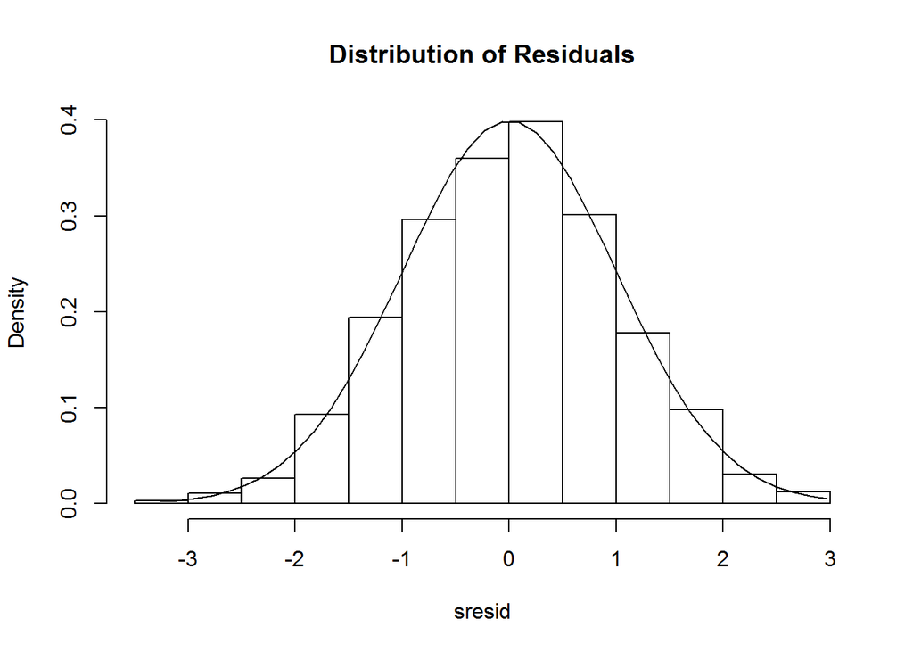

Based on the normality plot it appears that residual distribution is normal. This indicates the mean of the difference between our predictions.

plot residuals with respect to predicted value for randomness:

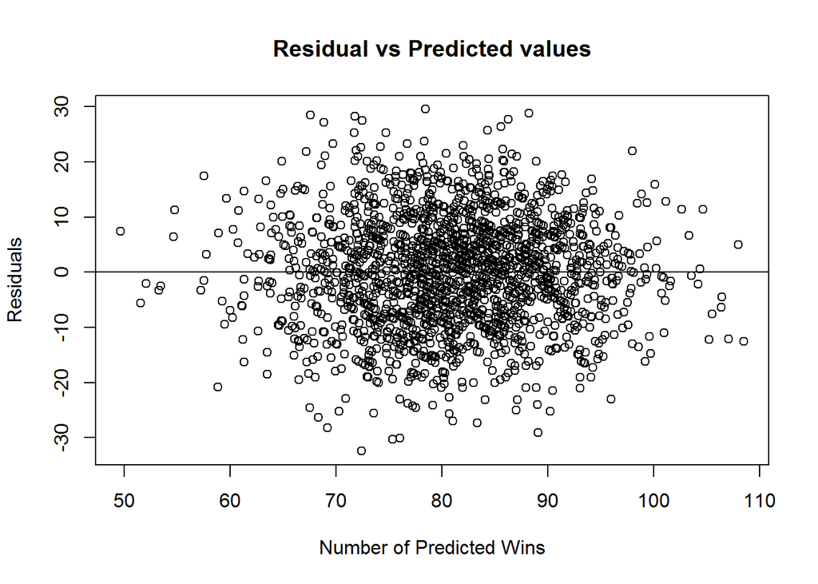

Distribution of residual values are random around base line and do not show any pattern around base line.

### Evaluate homoscedasticity:

```
## Non-constant Variance Score Test
## Variance formula: ~ fitted.values
## Chisquare = 10.99181    Df = 1     p = 0.0009151536
```

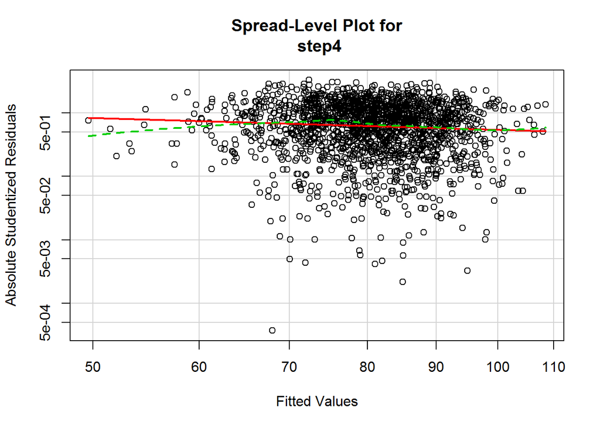

```
##
## Suggested power transformation:  1.626347
```

### Analysis of collinearity:

Analysis of collinearity

| TEAM_BATTING_H | 16.889895 |
| --- | --- |
| TEAM_BATTING_2B | 12.700340 |
| TEAM_BATTING_3B | 1.763097 |
| TEAM_BATTING_HR | 15.511898 |
| TEAM_BATTING_BB | 18.849834 |
| TEAM_BASERUN_SB | 1.249784 |
| TEAM_FIELDING_E | 6.657638 |
| TEAM_FIELDING_DP | 1.191288 |
| TEAM_PITCHING_BB | 17.122218 |
| TEAM_PITCHING_H | 16.437776 |
| TEAM_PITCHING_HR | 15.376065 |
| TEAM_PITCHING_SO | 2.176509 |
| TEAM_BATTING_H_NEW | 12.929265 |
| TEAM_BATTING_2B_NEW | 12.666855 |
| TEAM_FIELDING_E_NEW | 6.182960 |
| TEAM_PITCHING_BB_NEW | 7.639399 |
| TEAM_BASERUN_SB_SIN | 1.006246 |
| TEAM_BATTING_HBP_Missing | 1.246500 |
| TEAM_BASERUN_CS_Missing | 1.376209 |
| Hits_R | 187.163514 |
| Strikeout_R | 186.803538 |

Variables have been tested with variance inflation factors (VIF). If any variable has value which is greater than 3 then the highest value variable been removed from model and model performance has been evaluated. Following are the out comes from this assessment steps-

pass 3-pass 9- Based on that variance inflation factors (VIF) step 3- step 9 was followed by removing one variable at a time to reduce the VIF measure below 3 for all variable and without compromising too much on model performance(adjusted R^2 value). In final model adjusted R^2 value is 0.4037. That means around 40.37 % variability can be explained by this model. Also all the variables are relevant and having p value less than 0.05.

```
##           TEAM_BATTING_H          TEAM_BATTING_2B          TEAM_BATTING_3B
##                16.863430                12.698393                 1.763056
##          TEAM_BATTING_HR          TEAM_BATTING_BB          TEAM_BASERUN_SB
##                15.501371                18.849596                 1.247755
##          TEAM_FIELDING_E         TEAM_FIELDING_DP         TEAM_PITCHING_BB
##                 6.657283                 1.191067                17.121561
##          TEAM_PITCHING_H         TEAM_PITCHING_HR         TEAM_PITCHING_SO
##                16.395815                15.362614                 2.174531
##       TEAM_BATTING_H_NEW      TEAM_BATTING_2B_NEW      TEAM_FIELDING_E_NEW
##                12.928182                12.663764                 6.182897
##     TEAM_PITCHING_BB_NEW      TEAM_BASERUN_SB_SIN TEAM_BATTING_HBP_Missing
##                 7.639379                 1.006246                 1.246453
##  TEAM_BASERUN_CS_Missing              Strikeout_R
##                 1.375620                10.545014
```

```
##         TEAM_BATTING_3B         TEAM_BASERUN_SB         TEAM_FIELDING_E
##                1.727409                1.224382                1.767441
##        TEAM_FIELDING_DP        TEAM_PITCHING_HR        TEAM_PITCHING_SO
##                1.182640                2.069750                2.066239
##      TEAM_BATTING_H_NEW     TEAM_BATTING_2B_NEW    TEAM_PITCHING_BB_NEW
##                1.949900                1.597064                1.192712
##     TEAM_BASERUN_SB_SIN TEAM_BASERUN_CS_Missing             Strikeout_R
##                1.003535                1.329079                1.284631
```

```
##
## Call:
## lm(formula = TARGET_WINS ~ . - Hits_R - TEAM_BATTING_BB - TEAM_BATTING_H -
##     TEAM_BATTING_HR - TEAM_BATTING_2B - TEAM_PITCHING_H - TEAM_PITCHING_BB -
##     TEAM_FIELDING_E_NEW - TEAM_BATTING_HBP_Missing, data = data_step4)
##
## Residuals:
##     Min      1Q  Median      3Q     Max
## -32.740  -7.022   0.108   7.101  28.685
##
## Coefficients:
##                          Estimate Std. Error t value Pr(>|t|)
## (Intercept)             40.283276   8.906321   4.523 6.49e-06 ***
## TEAM_BATTING_3B          0.172848   0.018879   9.155  < 2e-16 ***
## TEAM_BASERUN_SB          0.071631   0.005507  13.008  < 2e-16 ***
## TEAM_FIELDING_E         -0.120338   0.007257 -16.583  < 2e-16 ***
## TEAM_FIELDING_DP        -0.106677   0.012368  -8.625  < 2e-16 ***
## TEAM_PITCHING_HR         0.094122   0.008705  10.812  < 2e-16 ***
## TEAM_PITCHING_SO        -0.019500   0.002206  -8.839  < 2e-16 ***
## TEAM_BATTING_H_NEW       0.032683   0.004342   7.528 8.05e-14 ***
## TEAM_BATTING_2B_NEW     -0.056302   0.008926  -6.307 3.55e-10 ***
## TEAM_PITCHING_BB_NEW     0.033202   0.003093  10.736  < 2e-16 ***
## TEAM_BASERUN_SB_SIN     -0.668686   0.339924  -1.967 0.049316 *
## TEAM_BASERUN_CS_Missing -4.062390   0.803315  -5.057 4.69e-07 ***
## Strikeout_R             17.050630   4.940275   3.451 0.000571 ***
## ---
## Signif. codes:  0 '***' 0.001 '**' 0.01 '*' 0.05 '.' 0.1 ' ' 1
##
## Residual standard error: 10.16 on 1822 degrees of freedom
##   (441 observations deleted due to missingness)
## Multiple R-squared:  0.4076, Adjusted R-squared:  0.4037
## F-statistic: 104.5 on 12 and 1822 DF,  p-value: < 2.2e-16
```

Final model was derived after number of iterations of variable eliminations were carried out. VIF values in the final model among variables < 3. In this scenario a model with slightly less performance was selected to avoid collinearity effect among variables and reduced complexity. Final model all the variables are relevant and having p value less than 0.05.

### Test Data

We will now run the final model on the test data.  
Prior to this, we still have to carry out the same transformations that we did to the train dataset to the test dataset. Below is a quick summary after the transformations:

```
##  TEAM_BATTING_H TEAM_BATTING_2B TEAM_BATTING_3B  TEAM_BATTING_HR
##  Min.   : 819   Min.   : 44.0   Min.   : 14.00   Min.   :  0.00
##  1st Qu.:1387   1st Qu.:210.0   1st Qu.: 35.00   1st Qu.: 44.50
##  Median :1455   Median :239.0   Median : 52.00   Median :101.00
##  Mean   :1469   Mean   :241.3   Mean   : 55.91   Mean   : 95.63
##  3rd Qu.:1548   3rd Qu.:278.5   3rd Qu.: 72.00   3rd Qu.:135.50
##  Max.   :2170   Max.   :376.0   Max.   :155.00   Max.   :242.00
##
##  TEAM_BATTING_BB TEAM_BASERUN_SB TEAM_FIELDING_E  TEAM_FIELDING_DP
##  Min.   : 15.0   Min.   :  0.0   Min.   :  73.0   Min.   : 69.0
##  1st Qu.:436.5   1st Qu.: 59.0   1st Qu.: 131.0   1st Qu.:131.0
##  Median :509.0   Median : 92.0   Median : 163.0   Median :148.0
##  Mean   :499.0   Mean   :123.7   Mean   : 249.7   Mean   :146.1
##  3rd Qu.:565.5   3rd Qu.:151.8   3rd Qu.: 252.0   3rd Qu.:164.0
##  Max.   :792.0   Max.   :580.0   Max.   :1568.0   Max.   :204.0
##                  NA's   :13                       NA's   :31
##  TEAM_PITCHING_BB TEAM_PITCHING_H TEAM_PITCHING_HR TEAM_PITCHING_SO
##  Min.   : 136.0   Min.   : 1155   Min.   :  0.0    Min.   :   0.0
##  1st Qu.: 471.0   1st Qu.: 1426   1st Qu.: 52.0    1st Qu.: 613.0
##  Median : 526.0   Median : 1515   Median :104.0    Median : 745.0
##  Mean   : 552.4   Mean   : 1813   Mean   :102.1    Mean   : 799.7
##  3rd Qu.: 606.5   3rd Qu.: 1681   3rd Qu.:142.5    3rd Qu.: 938.0
##  Max.   :2008.0   Max.   :22768   Max.   :336.0    Max.   :9963.0
##                                                    NA's   :18
##  TEAM_BATTING_H_NEW TEAM_BATTING_2B_NEW TEAM_FIELDING_E_NEW
##  Min.   :1149       Min.   :116.0       Min.   : 73.0
##  1st Qu.:1387       1st Qu.:210.0       1st Qu.:131.0
##  Median :1455       Median :239.0       Median :163.0
##  Mean   :1467       Mean   :242.1       Mean   :238.8
##  3rd Qu.:1548       3rd Qu.:278.5       3rd Qu.:252.0
##  Max.   :1775       Max.   :376.0       Max.   :660.2
##
##  TEAM_PITCHING_BB_NEW TEAM_BASERUN_SB_SIN TEAM_BATTING_HBP_Missing
##  Min.   :286.0        Min.   :-0.99975    Min.   :0.00000
##  1st Qu.:471.0        1st Qu.:-0.68318    1st Qu.:0.00000
##  Median :526.0        Median : 0.14546    Median :0.00000
##  Mean   :542.3        Mean   : 0.06904    Mean   :0.07336
##  3rd Qu.:606.5        3rd Qu.: 0.81676    3rd Qu.:0.00000
##  Max.   :805.0        Max.   : 0.99952    Max.   :1.00000
##                       NA's   :13
##  TEAM_BASERUN_CS_Missing     Hits_R        Strikeout_R
##  Min.   :0.0000          Min.   :0.0679   Min.   :0.0679
##  1st Qu.:0.0000          1st Qu.:0.9382   1st Qu.:0.9388
##  Median :1.0000          Median :0.9506   Median :0.9508
##  Mean   :0.6641          Mean   :0.9168   Mean   :0.9204
##  3rd Qu.:1.0000          3rd Qu.:1.0000   3rd Qu.:1.0000
##  Max.   :1.0000          Max.   :1.0187   Max.   :1.0189
##                                           NA's   :20
```

Now that we have the test data prepared, we will go ahead and run the final model on this dataset.

```r
summary(step4_final)
```

```
##
## Call:
## lm(formula = TARGET_WINS ~ . - Hits_R - TEAM_BATTING_BB - TEAM_BATTING_H -
##     TEAM_BATTING_HR - TEAM_BATTING_2B - TEAM_PITCHING_H - TEAM_PITCHING_BB -
##     TEAM_FIELDING_E_NEW - TEAM_BATTING_HBP_Missing, data = data_step4)
##
## Residuals:
##     Min      1Q  Median      3Q     Max
## -32.740  -7.022   0.108   7.101  28.685
##
## Coefficients:
##                          Estimate Std. Error t value Pr(>|t|)
## (Intercept)             40.283276   8.906321   4.523 6.49e-06 ***
## TEAM_BATTING_3B          0.172848   0.018879   9.155  < 2e-16 ***
## TEAM_BASERUN_SB          0.071631   0.005507  13.008  < 2e-16 ***
## TEAM_FIELDING_E         -0.120338   0.007257 -16.583  < 2e-16 ***
## TEAM_FIELDING_DP        -0.106677   0.012368  -8.625  < 2e-16 ***
## TEAM_PITCHING_HR         0.094122   0.008705  10.812  < 2e-16 ***
## TEAM_PITCHING_SO        -0.019500   0.002206  -8.839  < 2e-16 ***
## TEAM_BATTING_H_NEW       0.032683   0.004342   7.528 8.05e-14 ***
## TEAM_BATTING_2B_NEW     -0.056302   0.008926  -6.307 3.55e-10 ***
## TEAM_PITCHING_BB_NEW     0.033202   0.003093  10.736  < 2e-16 ***
## TEAM_BASERUN_SB_SIN     -0.668686   0.339924  -1.967 0.049316 *
## TEAM_BASERUN_CS_Missing -4.062390   0.803315  -5.057 4.69e-07 ***
## Strikeout_R             17.050630   4.940275   3.451 0.000571 ***
## ---
## Signif. codes:  0 '***' 0.001 '**' 0.01 '*' 0.05 '.' 0.1 ' ' 1
##
## Residual standard error: 10.16 on 1822 degrees of freedom
##   (441 observations deleted due to missingness)
## Multiple R-squared:  0.4076, Adjusted R-squared:  0.4037
## F-statistic: 104.5 on 12 and 1822 DF,  p-value: < 2.2e-16
```

```r
pred_test <- predict(step4_final, data_test, interval="prediction", level=0.95)

#pred_test

final_predicted_DS <- cbind(data_test, pred_test)
```

Below is the result of the prediction for the 259 cases that we had for evaluation.

```r
kable(final_predicted_DS)
```

| TEAM_BATTING_H | TEAM_BATTING_2B | TEAM_BATTING_3B | TEAM_BATTING_HR | TEAM_BATTING_BB | TEAM_BASERUN_SB | TEAM_FIELDING_E | TEAM_FIELDING_DP | TEAM_PITCHING_BB | TEAM_PITCHING_H | TEAM_PITCHING_HR | TEAM_PITCHING_SO | TEAM_BATTING_H_NEW | TEAM_BATTING_2B_NEW | TEAM_FIELDING_E_NEW | TEAM_PITCHING_BB_NEW | TEAM_BASERUN_SB_SIN | TEAM_BATTING_HBP_Missing | TEAM_BASERUN_CS_Missing | Hits_R | Strikeout_R | fit | lwr | upr |
| --- | --- | --- | --- | --- | --- | --- | --- | --- | --- | --- | --- | --- | --- | --- | --- | --- | --- | --- | --- | --- | --- | --- | --- |
| 1209 | 170 | 33 | 83 | 447 | 62 | 140 | 156 | 447 | 1209 | 83 | 1080 | 1209.0 | 170.0 | 140.0 | 447.0 | -0.7391807 | 0 | 1 | 1.0000000 | 1.0000000 | 61.95756 | 41.95539 | 81.95973 |
| 1221 | 151 | 29 | 88 | 516 | 54 | 135 | 164 | 516 | 1221 | 88 | 929 | 1221.0 | 151.0 | 135.0 | 516.0 | -0.5587890 | 0 | 1 | 1.0000000 | 1.0000000 | 67.48880 | 47.50134 | 87.47625 |
| 1395 | 183 | 29 | 93 | 509 | 59 | 156 | 153 | 509 | 1395 | 93 | 816 | 1395.0 | 183.0 | 156.0 | 509.0 | 0.6367380 | 0 | 1 | 1.0000000 | 1.0000000 | 72.02085 | 52.04038 | 92.00132 |
| 1539 | 309 | 29 | 159 | 486 | 148 | 124 | 154 | 486 | 1539 | 159 | 914 | 1539.0 | 309.0 | 124.0 | 486.0 | -0.3383334 | 1 | 1 | 1.0000000 | 1.0000000 | 83.94187 | 63.97236 | 103.91138 |
| 1445 | 203 | 68 | 5 | 95 | NA | 616 | 130 | 257 | 3902 | 14 | 1123 | 1445.0 | 203.0 | 660.2 | 384.4 | NA | 0 | 0 | 0.3703229 | 0.3704363 | NA | NA | NA |
| 1431 | 236 | 53 | 10 | 215 | NA | 572 | 105 | 420 | 2793 | 20 | 736 | 1431.0 | 236.0 | 660.2 | 420.0 | NA | 0 | 0 | 0.5123523 | 0.5122283 | NA | NA | NA |
| 1430 | 219 | 55 | 37 | 568 | 365 | 490 | NA | 613 | 1544 | 40 | 569 | 1430.0 | 219.0 | 660.2 | 613.0 | 0.5440464 | 0 | 0 | 0.9261658 | 0.9261863 | NA | NA | NA |
| 1385 | 158 | 42 | 33 | 356 | 185 | 328 | 104 | 418 | 1626 | 39 | 715 | 1385.0 | 158.0 | 328.0 | 418.0 | 0.3466212 | 0 | 0 | 0.8517835 | 0.8517483 | 64.49740 | 44.42873 | 84.56607 |
| 1259 | 177 | 78 | 23 | 466 | 150 | 226 | 132 | 497 | 1342 | 25 | 734 | 1259.0 | 177.0 | 226.0 | 497.0 | -0.7148764 | 0 | 0 | 0.9381520 | 0.9386921 | 75.43949 | 55.43370 | 95.44527 |
| 1397 | 212 | 42 | 58 | 452 | 52 | 184 | 145 | 482 | 1489 | 62 | 622 | 1397.0 | 212.0 | 184.0 | 482.0 | 0.9866276 | 0 | 0 | 0.9382136 | 0.9389068 | 72.43865 | 52.44376 | 92.43354 |
| 1427 | 243 | 40 | 50 | 495 | 64 | 200 | 183 | 521 | 1501 | 53 | 673 | 1427.0 | 243.0 | 200.0 | 521.0 | 0.9200260 | 0 | 0 | 0.9506995 | 0.9509658 | 65.91194 | 45.89125 | 85.93262 |
| 1496 | 239 | 55 | 164 | 462 | 48 | 150 | 178 | 486 | 1574 | 173 | 705 | 1496.0 | 239.0 | 150.0 | 486.0 | -0.7682547 | 0 | 1 | 0.9504447 | 0.9503546 | 82.95384 | 62.96674 | 102.94094 |
| 1420 | 223 | 57 | 186 | 511 | 31 | 137 | 167 | 538 | 1494 | 196 | 790 | 1420.0 | 223.0 | 137.0 | 538.0 | -0.4040376 | 0 | 1 | 0.9504685 | 0.9506329 | 85.23150 | 65.23001 | 105.23300 |
| 1460 | 232 | 22 | 176 | 503 | 27 | 125 | 160 | 529 | 1536 | 185 | 715 | 1460.0 | 232.0 | 125.0 | 529.0 | 0.9563759 | 0 | 1 | 0.9505208 | 0.9510490 | 81.11248 | 61.11277 | 101.11219 |
| 1411 | 195 | 22 | 141 | 485 | 59 | 115 | 114 | 485 | 1411 | 141 | 665 | 1411.0 | 195.0 | 115.0 | 485.0 | 0.6367380 | 0 | 1 | 1.0000000 | 1.0000000 | 86.41805 | 66.39136 | 106.44473 |
| 1434 | 192 | 30 | 153 | 434 | 57 | 146 | 180 | 434 | 1434 | 153 | 747 | 1434.0 | 192.0 | 146.0 | 434.0 | 0.4361648 | 0 | 1 | 1.0000000 | 1.0000000 | 75.77829 | 55.78884 | 95.76774 |
| 1297 | 204 | 22 | 130 | 491 | 84 | 154 | 126 | 497 | 1313 | 132 | 1021 | 1297.0 | 204.0 | 154.0 | 497.0 | 0.7331903 | 0 | 1 | 0.9878142 | 0.9872674 | 70.33050 | 50.36349 | 90.29750 |
| 1446 | 284 | 25 | 166 | 565 | 77 | 115 | 172 | 572 | 1464 | 168 | 1054 | 1446.0 | 284.0 | 115.0 | 572.0 | 0.9995202 | 1 | 1 | 0.9877049 | 0.9876660 | 75.56302 | 55.60093 | 95.52511 |
| 1276 | 162 | 52 | 17 | 383 | 138 | 301 | 83 | 406 | 1351 | 18 | NA | 1276.0 | 162.0 | 301.0 | 406.0 | -0.2280523 | 0 | 0 | 0.9444856 | NA | NA | NA | NA |
| 1715 | 322 | 72 | 116 | 527 | 90 | 232 | 174 | 558 | 1816 | 123 | 420 | 1715.0 | 322.0 | 232.0 | 558.0 | 0.8939967 | 0 | 1 | 0.9443833 | 0.9452381 | 83.98767 | 63.96547 | 104.00986 |
| 1520 | 295 | 68 | 49 | 628 | 77 | 166 | 158 | 669 | 1620 | 52 | 489 | 1520.0 | 295.0 | 166.0 | 669.0 | 0.9995202 | 0 | 1 | 0.9382716 | 0.9386503 | 82.63543 | 62.63120 | 102.63966 |
| 1597 | 291 | 38 | 98 | 629 | 54 | 155 | 174 | 670 | 1702 | 104 | 600 | 1597.0 | 291.0 | 155.0 | 670.0 | -0.5587890 | 0 | 1 | 0.9383079 | 0.9383333 | 81.96077 | 61.97373 | 101.94782 |
| 1453 | 256 | 67 | 105 | 653 | 40 | 179 | 153 | 701 | 1559 | 113 | 698 | 1453.0 | 256.0 | 179.0 | 701.0 | 0.7451132 | 0 | 1 | 0.9320077 | 0.9326648 | 81.58358 | 61.59820 | 101.56897 |
| 1378 | 225 | 26 | 118 | 533 | 18 | 160 | 174 | 561 | 1450 | 124 | 712 | 1378.0 | 225.0 | 160.0 | 561.0 | -0.7509872 | 0 | 1 | 0.9503448 | 0.9508427 | 69.68569 | 49.70796 | 89.66342 |
| 1516 | 277 | 24 | 152 | 431 | 89 | 105 | 164 | 431 | 1516 | 152 | 902 | 1516.0 | 277.0 | 105.0 | 431.0 | 0.8600694 | 1 | 1 | 1.0000000 | 1.0000000 | 78.06869 | 58.09504 | 98.04234 |
| 1556 | 288 | 20 | 164 | 474 | 121 | 102 | 156 | 474 | 1556 | 164 | 878 | 1556.0 | 288.0 | 102.0 | 474.0 | 0.9988152 | 1 | 1 | 1.0000000 | 1.0000000 | 84.50430 | 64.51851 | 104.49008 |
| 1499 | 183 | 28 | 3 | 83 | NA | 1224 | NA | 286 | 5167 | 10 | 0 | 1499.0 | 183.0 | 660.2 | 286.0 | NA | 0 | 0 | 0.2901103 | NaN | NA | NA | NA |
| 1464 | 263 | 58 | 47 | 385 | 63 | 232 | 146 | 405 | 1540 | 49 | 504 | 1464.0 | 263.0 | 232.0 | 405.0 | 0.1673557 | 0 | 1 | 0.9506494 | 0.9503968 | 64.62996 | 44.62795 | 84.63197 |
| 1558 | 318 | 66 | 32 | 634 | 83 | 218 | 130 | 667 | 1639 | 34 | 462 | 1558.0 | 318.0 | 218.0 | 667.0 | 0.9683645 | 0 | 1 | 0.9505796 | 0.9502165 | 78.37991 | 58.33718 | 98.42264 |
| 1502 | 308 | 36 | 39 | 432 | 45 | 199 | 135 | 460 | 1601 | 42 | 642 | 1502.0 | 308.0 | 199.0 | 460.0 | 0.8509035 | 0 | 1 | 0.9381636 | 0.9376947 | 61.19345 | 41.14357 | 81.24333 |

[output cut: 229 more lines]

The histogram of the predicted wins is as below:

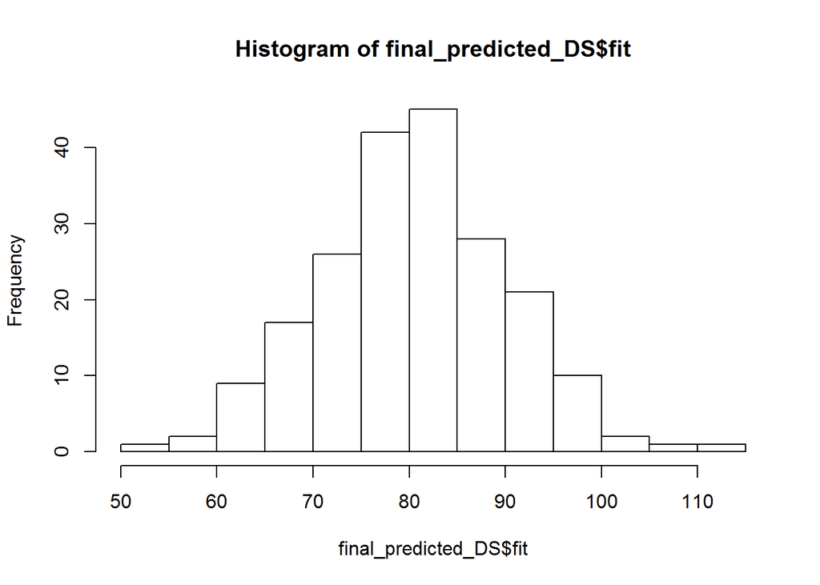

```r
hist(final_predicted_DS$fit)
```

#### Conclusion: